# Task 1

We first import required libraries.

```python
import os
import pandas as pd
from sklearn.preprocessing import StandardScaler
from sklearn.decomposition import PCA
import matplotlib.pyplot as plt
import numpy as np
import warnings
warnings.filterwarnings("ignore")
```

Then, we import CSV file, without including headers in the data.

```python
os.chdir('/Users/yunusutaro/Desktop/IE 582 Projects/Homework -2')
data = pd.read_csv("Musk.csv", header = None)
```

Then, we determine our features and target vectors in the dataset. Subtasks requires us to execute operations with respect to bag number, rather than molecule being musk or not.

```python
x = data.iloc[:, 2:].values
x2 = data.iloc[:, 2:]
y = data.iloc[:, 1]
z = data.iloc[:, 0]
```

Additionally, standard scaling operation will be applied before PCA.

```python
x = StandardScaler().fit_transform(x)
```

Then, we apply PCA.

```python
pca = PCA(n_components=166)
pca.fit(x)
print(pca.explained_variance_ratio_)
```

```
[3.11881251e-01 1.39219234e-01 7.61802576e-02 5.14303185e-02
 4.91966754e-02 4.07815230e-02 3.24633250e-02 3.04263124e-02
 1.99173553e-02 1.71714021e-02 1.54904284e-02 1.43177430e-02
 1.32981111e-02 1.27031481e-02 1.09215467e-02 9.98381724e-03
 8.65832673e-03 8.16555960e-03 7.56715166e-03 7.13998636e-03
 6.75637111e-03 6.36966183e-03 6.32002536e-03 5.83788520e-03
 5.59090549e-03 5.23176235e-03 4.94740157e-03 4.89314027e-03
 4.66981337e-03 4.42980033e-03 4.00784547e-03 3.99258747e-03
 3.84467339e-03 3.32509428e-03 2.93506662e-03 2.83849130e-03
 2.66548926e-03 2.53476215e-03 2.43331414e-03 2.05205815e-03
 2.00160295e-03 1.86561088e-03 1.78371770e-03 1.65442343e-03
 1.62273625e-03 1.49195344e-03 1.43977458e-03 1.35134658e-03
 1.23597893e-03 1.19328574e-03 1.13848816e-03 1.08010364e-03
 1.03961855e-03 9.59507892e-04 9.03418439e-04 8.67730983e-04
 8.28068093e-04 7.77229544e-04 7.57733862e-04 7.10797678e-04
 6.39343870e-04 6.18073824e-04 5.48166544e-04 5.42394720e-04
 5.18549020e-04 4.70435070e-04 4.55039093e-04 4.20782363e-04
 3.96015332e-04 3.74946146e-04 3.43886785e-04 3.34854506e-04
 3.25410770e-04 3.20272652e-04 3.18814732e-04 2.92797484e-04
 2.81469063e-04 2.63433786e-04 2.57487284e-04 2.45149434e-04
 2.22161127e-04 2.13761660e-04 2.04430387e-04 2.00950882e-04
 1.83278159e-04 1.76170268e-04 1.72018736e-04 1.69308338e-04
 1.64760811e-04 1.44458613e-04 1.38116870e-04 1.32119197e-04
 1.26225730e-04 1.20985042e-04 1.13579336e-04 1.08573369e-04
 1.05638653e-04 1.02150823e-04 9.72769818e-05 9.40109902e-05
 9.08135174e-05 8.12994210e-05 7.98776457e-05 7.93015120e-05
 7.81113149e-05 7.50629907e-05 7.20291241e-05 6.56865352e-05
 6.00141248e-05 5.88249360e-05 5.80006339e-05 5.50010499e-05
 5.36673531e-05 4.83754378e-05 4.65929748e-05 4.15493586e-05
 4.04550045e-05 3.80824731e-05 3.61197760e-05 3.41877175e-05
 3.27252410e-05 3.19064288e-05 3.04048659e-05 2.85618877e-05
 2.73589718e-05 2.63153762e-05 2.54163804e-05 2.28933543e-05
 2.22045866e-05 2.13971650e-05 1.98016890e-05 1.93236782e-05
 1.77966781e-05 1.75716544e-05 1.64408297e-05 1.53180831e-05
 1.40033446e-05 1.33095760e-05 1.21918127e-05 1.19695545e-05
 1.16472933e-05 9.68511747e-06 9.38795218e-06 9.09265919e-06
 8.22260714e-06 7.96342955e-06 7.20443467e-06 7.05932696e-06
 6.85573909e-06 6.09652207e-06 5.68058158e-06 4.94353767e-06
 4.62464020e-06 4.53836773e-06 3.72502997e-06 3.54426151e-06
 3.29896520e-06 3.14134459e-06 2.63147318e-06 2.25304890e-06
 1.92296334e-06 1.78873880e-06 1.68105886e-06 1.20008025e-06
 1.06884207e-06 7.29505527e-07]
```

```python
pca = PCA(n_components=8)
principalComponents = pca.fit_transform(x)
principalDf = pd.DataFrame(data = principalComponents
             , columns = ['principal component 1', 'principal component 2',
                           'principal component 3', 'principal component 4'
                          , 'principal component 5', 'principal component 6'
                          , 'principal component 7', 'principal component 8'])
finalDf = pd.concat([principalDf, y], axis = 1)
finalDf = finalDf.rename({1: 'bag'}, axis=1)
```

We can display the dataframe of 8 principal components. Column named "bag" refers to the bag number.

```python
finalDf
```

|  | principal component 1 | principal component 2 | principal component 3 | principal component 4 | principal component 5 | principal component 6 | principal component 7 | principal component 8 | bag |
| --- | --- | --- | --- | --- | --- | --- | --- | --- | --- |
| 0 | 0.787850 | 8.664480 | 2.433177 | -8.109256 | 0.140986 | -2.405274 | -3.270312 | -2.071979 | 1 |
| 1 | 0.782505 | 8.544104 | 2.636037 | -7.014406 | 1.095515 | -1.003332 | -1.930490 | -3.730391 | 1 |
| 2 | 0.248081 | 8.360294 | 2.454432 | -8.106509 | 0.831239 | -1.724215 | -2.348840 | -2.719549 | 1 |
| 3 | 1.356422 | 9.106098 | 2.639127 | -7.042917 | 0.458120 | -1.659686 | -2.814254 | -3.161062 | 1 |
| 4 | 1.459051 | 8.685006 | -0.016682 | -8.001193 | 2.830049 | -1.576117 | -0.336930 | -0.404053 | 2 |
| 5 | 1.432688 | 8.523412 | 0.187185 | -6.934197 | 3.853108 | -0.190251 | 1.024651 | -2.039468 | 2 |
| 6 | 0.920453 | 8.368257 | -0.116682 | -7.901160 | 3.785049 | -0.909744 | 0.537838 | -1.065377 | 2 |
| 7 | 2.034320 | 9.084437 | 0.200315 | -6.953655 | 3.152031 | -0.854719 | 0.123416 | -1.471346 | 2 |
| 8 | -0.140602 | 10.165856 | -0.534598 | -4.495166 | 5.006010 | -2.120330 | 1.663019 | -2.092503 | 3 |
| 9 | 3.608956 | 10.120544 | -1.387411 | -7.153864 | -1.717092 | -2.056576 | 1.052212 | 0.413469 | 3 |
| 10 | 3.421836 | 10.890055 | -0.029250 | -5.543338 | -0.785751 | -1.066326 | -2.865742 | -2.683817 | 4 |
| 11 | 2.582227 | 9.730890 | -0.293022 | -6.645800 | -0.963831 | -1.831146 | -3.190432 | -2.516013 | 4 |
| 12 | -0.457387 | 10.569132 | 2.904398 | -5.423063 | 0.121113 | -3.491109 | -1.397045 | -2.980383 | 4 |
| 13 | 0.691253 | 10.264074 | -3.211107 | -2.493860 | 6.547654 | -2.772090 | 1.003341 | -2.219737 | 5 |
| 14 | 4.265263 | 10.083248 | -5.662968 | -3.507956 | 6.374934 | -4.000845 | -3.173988 | 1.429323 | 5 |
| 15 | 4.311438 | 9.923660 | -2.524883 | -7.872632 | -2.090335 | -2.019186 | 4.633949 | 2.206615 | 5 |
| 16 | -0.023933 | 9.041394 | 0.864071 | -6.865258 | 0.215632 | -2.224097 | 4.600644 | -0.162395 | 5 |
| 17 | 2.022708 | 12.482091 | 2.370385 | -5.332835 | 1.129006 | -2.521435 | 0.874107 | 3.775748 | 6 |
| 18 | 2.943967 | 9.693516 | -3.633108 | -5.653796 | 3.888136 | 1.029086 | -2.415755 | -0.568600 | 6 |
| 19 | -0.002889 | 5.247440 | 2.017309 | -5.385344 | 1.473911 | -2.461809 | 2.206199 | 0.382163 | 7 |
| 20 | 3.179804 | 5.866482 | -3.738684 | -4.559817 | 3.919545 | 0.056780 | -2.155771 | -0.448918 | 7 |
| 21 | 0.578336 | 3.108288 | 0.236517 | -6.955256 | 3.466788 | 1.439481 | 0.164234 | -0.445441 | 8 |
| 22 | 1.700061 | 1.983831 | 2.294143 | -6.291041 | 4.167296 | 0.458609 | 0.205316 | 0.387570 | 8 |
| 23 | -6.799058 | -1.717926 | 0.813892 | -1.914235 | -0.172348 | 2.740265 | 4.184821 | -1.004091 | 9 |
| 24 | -5.317210 | -1.329672 | -0.361122 | 0.026697 | 4.250938 | 2.669559 | 0.794238 | 0.255652 | 9 |
| 25 | 10.907603 | -1.672476 | 0.911387 | 1.400994 | 4.537837 | 1.800551 | -2.240859 | 1.553766 | 9 |
| 26 | -6.296220 | -1.791607 | -0.554436 | -0.359051 | 4.860857 | 3.081335 | 1.535105 | -0.909814 | 9 |
| 27 | 11.497196 | -3.727851 | 2.993862 | -2.018151 | -2.747101 | 1.560478 | -0.222670 | 2.921849 | 9 |
| 28 | 9.408593 | -4.637442 | 3.921405 | 0.367055 | -1.299967 | 3.268667 | -3.249139 | -0.473061 | 10 |
| 29 | 9.283526 | -1.796908 | 3.965916 | -0.186366 | -1.237667 | 2.077592 | -2.520691 | -0.680135 | 10 |
| ... | ... | ... | ... | ... | ... | ... | ... | ... | ... |
| 446 | -6.206856 | 0.103803 | 0.849804 | -0.280787 | -3.586890 | 0.680421 | -4.199665 | 2.016711 | 88 |
| 447 | -6.394994 | 0.534378 | 0.054380 | 1.089109 | -2.626745 | -0.701151 | -5.512937 | 1.015058 | 88 |
| 448 | -6.075771 | -0.195135 | 3.219603 | 0.492646 | -0.514409 | -0.060391 | -4.707075 | 1.478787 | 88 |
| 449 | -8.465000 | -3.429890 | 3.242532 | 0.397470 | -0.916359 | 1.421436 | -3.864519 | 1.310119 | 88 |
| 450 | -5.512633 | -1.631885 | 2.560815 | -1.900929 | -2.491061 | -0.183502 | -4.394941 | 3.057330 | 88 |
| 451 | -5.776507 | -0.918767 | -0.514258 | -1.425513 | -3.001912 | -2.365866 | -6.908644 | 1.985234 | 88 |
| 452 | -6.275032 | -0.668018 | 3.104116 | 0.092938 | -1.255982 | -0.297114 | -3.462461 | 2.127773 | 88 |
| 453 | -7.989271 | -3.418299 | 3.470876 | 0.371353 | -0.978453 | 1.314742 | -3.189734 | 1.299186 | 88 |
| 454 | -5.370532 | -1.651254 | 2.780935 | -1.824081 | -3.040223 | 0.292373 | -4.128326 | 3.060336 | 88 |
| 455 | -4.968836 | -2.117943 | 3.751618 | -1.360024 | -0.635668 | -1.314715 | -5.481094 | 2.867624 | 88 |
| 456 | -5.959971 | -0.755841 | 2.636669 | 0.670460 | -1.453444 | -0.724548 | -4.164140 | 1.900987 | 88 |
| 457 | -3.191732 | 14.053838 | -4.201780 | 7.687910 | -3.647938 | -0.435544 | 2.000824 | -4.485249 | 89 |
| 458 | -2.783517 | 14.152782 | -4.133312 | 7.773087 | -3.473313 | 0.291065 | 1.792530 | -3.619648 | 89 |
| 459 | -2.801589 | 14.202107 | -4.518471 | 7.063475 | -3.206053 | 2.309345 | 1.013075 | -3.439413 | 89 |
| 460 | -3.225591 | 14.034522 | -4.618765 | 7.016666 | -3.500040 | 2.434384 | 0.846797 | -4.196055 | 89 |
| 461 | -0.768178 | 13.683435 | -4.168812 | 5.365163 | -2.930354 | -1.913503 | 0.871315 | -5.076312 | 90 |
| 462 | -0.486498 | 13.802437 | -3.934980 | 5.651472 | -2.988577 | -1.837701 | 0.865124 | -4.137824 | 90 |
| 463 | -0.427524 | 13.710718 | -4.357586 | 4.974045 | -2.764936 | 0.038995 | 0.209219 | -3.978197 | 90 |
| 464 | -0.785282 | 13.680430 | -4.398991 | 4.640504 | -2.985161 | 0.133988 | 0.023316 | -4.858217 | 90 |
| 465 | 5.809472 | 15.054944 | 11.498487 | 6.636497 | 0.320495 | -0.267360 | 4.932706 | 5.999970 | 91 |
| 466 | 5.645732 | 14.992994 | 9.109322 | 9.431954 | 6.115863 | -0.803022 | 2.698598 | 5.927053 | 91 |
| 467 | 5.174730 | 15.022166 | 11.858259 | 8.864556 | 1.307672 | -1.380317 | 3.538346 | 5.626883 | 91 |
| 468 | -5.091249 | -0.752136 | -0.058811 | -0.617711 | 4.107614 | 2.991487 | 1.268258 | 1.796417 | 92 |
| 469 | 9.479440 | -2.319395 | 2.711735 | -0.409258 | -1.916908 | 2.046844 | 1.775383 | 0.808613 | 92 |
| 470 | 9.834739 | -2.000829 | 0.530257 | 1.709663 | 4.931494 | 2.713803 | -1.818286 | 0.263993 | 92 |
| 471 | -5.253664 | -1.294476 | 2.044729 | -2.697814 | -0.353112 | 2.124743 | 3.467472 | 3.236730 | 92 |
| 472 | -6.833537 | -0.135816 | -3.037247 | -1.026604 | 3.940065 | 1.408224 | -0.533394 | 2.066560 | 92 |
| 473 | 10.587193 | -2.892693 | 3.170439 | -0.966484 | -2.368987 | -2.765185 | 3.797592 | 0.070285 | 92 |
| 474 | -4.003161 | -0.307099 | -8.162897 | -0.059514 | 0.721592 | 0.307169 | -2.640764 | 1.384676 | 92 |
| 475 | 10.507496 | -2.668611 | 0.975763 | 1.381852 | 4.628440 | -3.035621 | 0.567570 | -0.341520 | 92 |

476 rows × 9 columns

By using seaborn library, we will be displaying the principal components pairwise. However, since 8 principal components has 28 different plots in 2D, we will only select several of them.

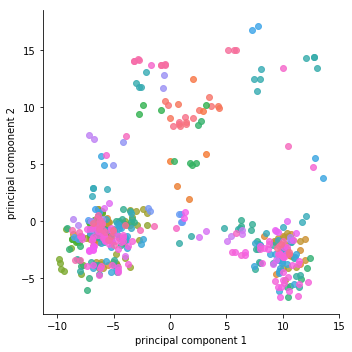

```python
import seaborn as sns


sns.lmplot(x="principal component 1", y= "principal component 2", data=finalDf,
           fit_reg=False, hue="bag", legend=False)
```

As seen above, when we plot Principal Component 1 vs Principal Component 2, we can interpret that especially in the southwest and southeast part of the graph, different bags are included in the same region, which tells that these principal components are not adequate in seperating the differences between the bags. We try that again for first and third component.

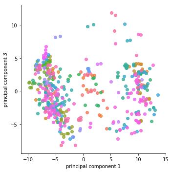

```python
sns.lmplot(x="principal component 1", y= "principal component 3", data=finalDf,
           fit_reg=False, hue='bag', legend=False)
```

We observe that spread of the bags on the plat are stacked into the left side of the graph. It is still better in representing most of the bags compared to the second component. We try the 4th component now.

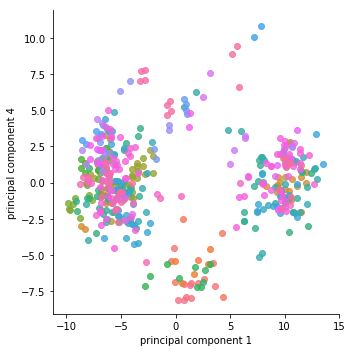

```python
sns.lmplot(x="principal component 1", y= "principal component 4", data=finalDf,
           fit_reg=False, hue='bag', legend=False)
```

We observe that the performance gets worse than the 3rd component. Next, we will plot 1st and 5th components.

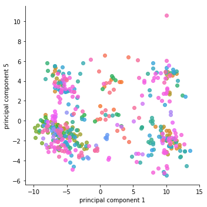

```python
sns.lmplot(x="principal component 1", y= "principal component 5", data=finalDf,
           fit_reg=False, hue='bag', legend=False)
```

Surprisingly, it is better than the previous graphs in the representation of distinct points. Alternatively, we will plot 2nd and 3rd component lastly.

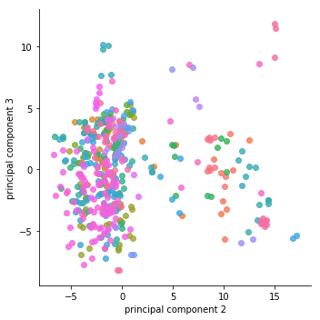

```python
sns.lmplot(x="principal component 2", y= "principal component 3", data=finalDf,
           fit_reg=False, hue='bag', legend=False)
```

The graph seems to be stacked to the left in these two components. Now, we will apply the PCA after we represent the instances in each bag by a single vector.

```python
alternatedf =  pd.concat([y ,x2], axis = 1)
alternatedf = alternatedf.groupby(1).mean()
alternatedf.insert(0, "Bag", alternatedf.index, True)
xnew = alternatedf.iloc[:, 1:].values
ynew = alternatedf.iloc[:, 0]
xnew = StandardScaler().fit_transform(xnew)
pca = PCA(n_components=8)
pca.fit(xnew)
print(pca.explained_variance_ratio_)
principalComponents2 = pca.fit_transform(xnew)
principalDf2 = pd.DataFrame(data = principalComponents2
             , columns = ['principal component 1', 'principal component 2',
                           'principal component 3', 'principal component 4'
                          , 'principal component 5', 'principal component 6'
                          , 'principal component 7', 'principal component 8'])
```

```
[0.26662286 0.19065605 0.13255029 0.10658653 0.05790991 0.04560838
 0.03036141 0.02141441]
```

Now, we plot several Principal Components in this new dataset.

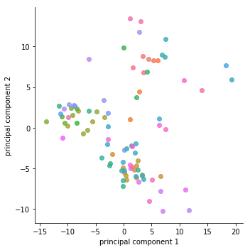

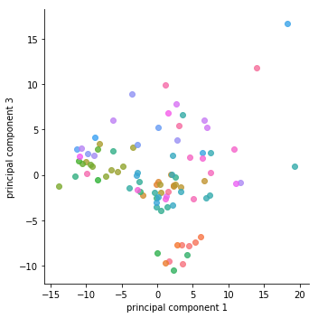

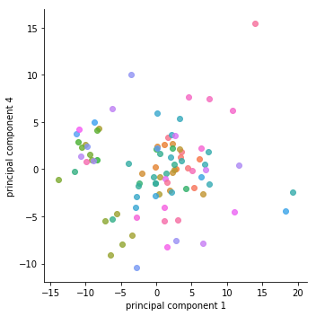

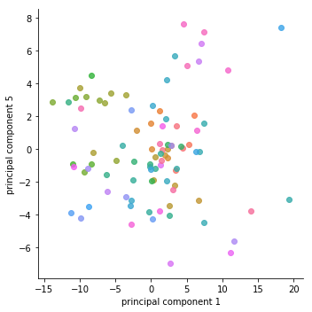

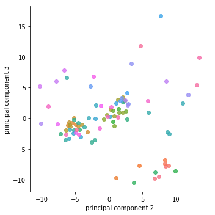

```python
ynew.reset_index(drop=True, inplace=True)
principalDf2.reset_index(drop=True, inplace=True)
finalDf2 = pd.concat([ynew, principalDf2], axis = 1)
sns.lmplot(x="principal component 1", y= "principal component 2", data=finalDf2,
           fit_reg=False, hue='Bag', legend=False)
sns.lmplot(x="principal component 1", y= "principal component 3", data=finalDf2,
           fit_reg=False, hue='Bag', legend=False)
sns.lmplot(x="principal component 1", y= "principal component 4", data=finalDf2,
           fit_reg=False, hue='Bag', legend=False)
sns.lmplot(x="principal component 1", y= "principal component 5", data=finalDf2,
           fit_reg=False, hue='Bag', legend=False)
sns.lmplot(x="principal component 2", y= "principal component 3", data=finalDf2,
           fit_reg=False, hue='Bag', legend=False)
```

As seen above, representation is a little bit improved compared to pre-operation. Especially, the plot of 1st and 4th principal components represent the bags better. Now, we will do the same for MDS.

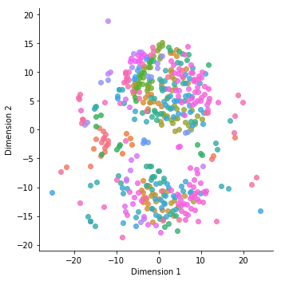

```python
from sklearn.manifold import MDS
seed = np.random.RandomState(seed=3)
embedding = MDS(n_components=2)
X_transformed = embedding.fit_transform(x)
X_transformed = pd.DataFrame(data = X_transformed,
             columns = ['Dimension 1', 'Dimension 2'])
finalDf2 = pd.concat([X_transformed, y], axis = 1)
finalDf2 = finalDf2.rename({1: 'bag'}, axis=1)
sns.lmplot(x="Dimension 1", y= "Dimension 2", data=finalDf2,
           fit_reg=False, hue='bag', legend=False)
```

As seen in the graph above, using MDS on dataset creates two clusters of datapoints. To check whether these datapoints represent the correct classes or not, we will use labels instead of bags this time.

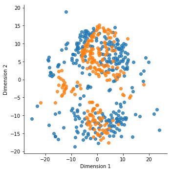

```python
finalDf2 = pd.concat([X_transformed, z], axis = 1)
finalDf2 = finalDf2.rename({0: 'class'}, axis=1)
sns.lmplot(x="Dimension 1", y= "Dimension 2", data=finalDf2,
           fit_reg=False, hue='class', legend=False)
```

As seen above, points on the center of dimension 1 have more tendency to be in the same class. Thus, MDS can be inferred to be successful in this operation. Now, we will apply MDS after showing instances in each bag by a single vector.

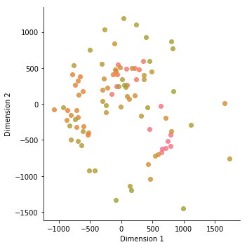

```python
alternatedf =  pd.concat([y ,x2], axis = 1)
alternatedf = alternatedf.groupby(1).mean()
alternatedf.insert(0, "Bag", alternatedf.index, True)
xnew = alternatedf.iloc[:, 1:].values
ynew = alternatedf.iloc[:, 0]
embedding = MDS(n_components=2)
X_transformed = embedding.fit_transform(xnew)
X_transformed = pd.DataFrame(data = X_transformed,
             columns = ['Dimension 1', 'Dimension 2'])
finalDf2 = pd.concat([X_transformed, y], axis = 1)
finalDf2 = finalDf2.rename({1: 'bag'}, axis=1)
sns.lmplot(x="Dimension 1", y= "Dimension 2", data=finalDf2,
           fit_reg=False, hue='bag', legend=False)
```